# STATS531 Final Project

**1. Introduction**  
Crude oil, is a naturally occurring, yellowish-black liquid found in geological formations, and is commonly refined into various fuels and chemicals that benefit people’s life$^{1}$. The price of oil influences the costs of other production and manufacturing around the world. For example, there is a direct correlation between the cost of gasoline or airplane fuel to the price of transporting goods and people$^{2}$.

Crude oil has always been one of the most widely used fuel sources around the world that is crucial to many industries. Crude oil is appreciated due to its scarcity and its global trade in markets. Since it is so widely welcomed and paid attention to, this project hopes to analyze the crude oil price with the following research question: **Can we use time series analysis to analyze crude oil prices?**

This project downloads data from *ourworldindata*, which offers us the crude oil price over a range of timeframes from 1861 annually$^{3}$.

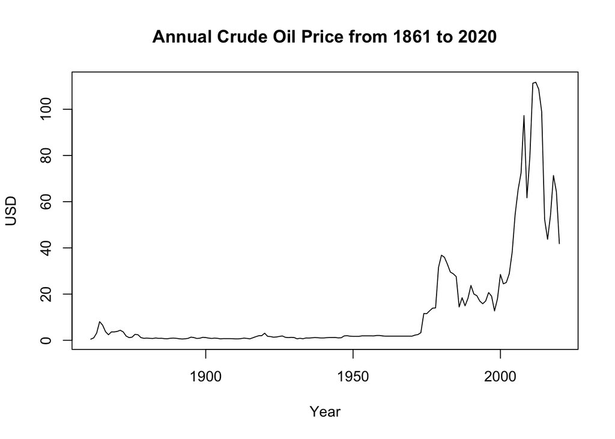

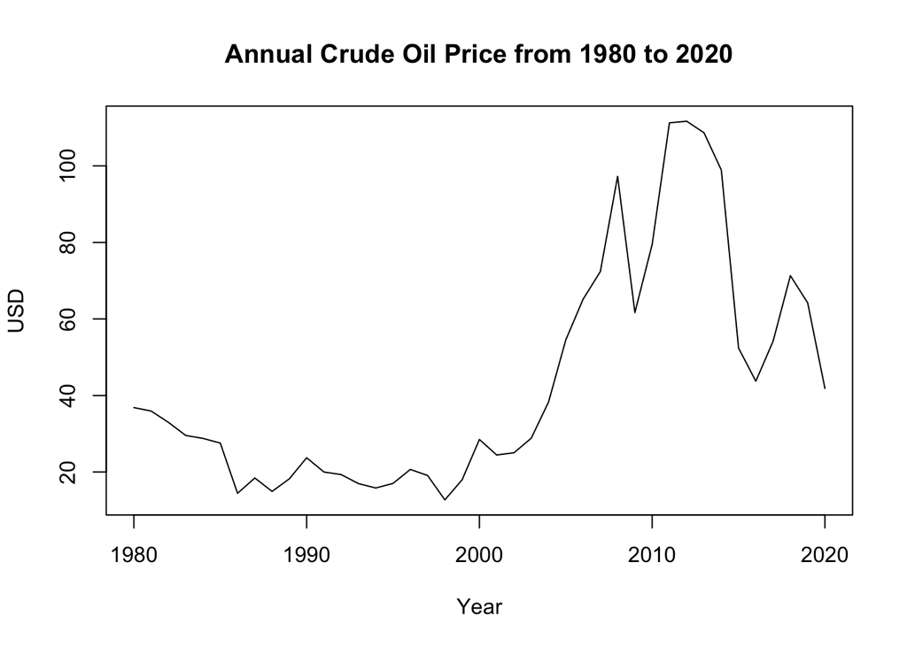

```
   Min. 1st Qu.  Median    Mean 3rd Qu.    Max.
   0.49    1.02    1.80   12.81   14.55  111.67
```

```
   Min. 1st Qu.  Median    Mean 3rd Qu.    Max.
  12.72   19.32   29.55   43.28   61.67  111.67
```

2.2 Autocorrelation and Data Preprocessing  
With the ACF figure below, we can see that there is substantial autocorrelation between crude oil price and its previous data, which suggests that it is not a stationary model, therefore driving us to take the log difference of crude oil price for further analysis.

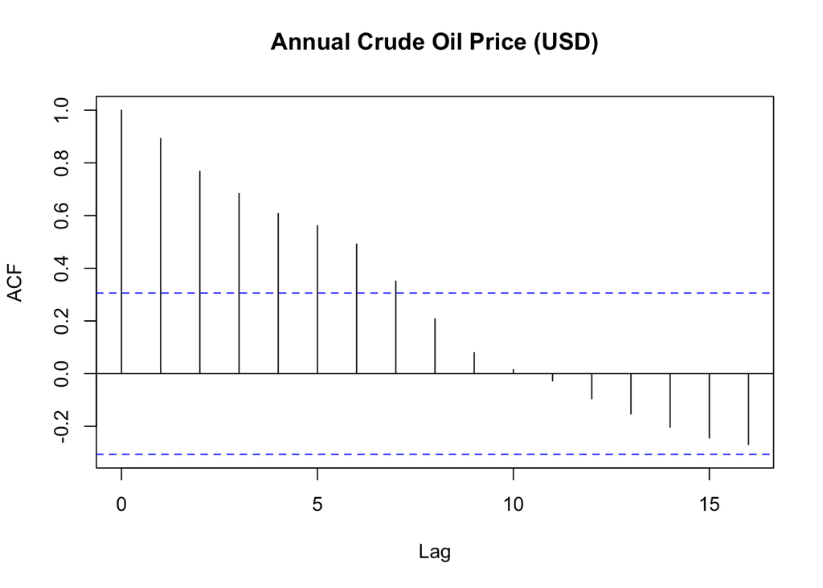

Since it is common to analyze the log returns of financial products rather than the raw difference in prices, it remains unsure whether log difference analysis could be used for crude oil prices. With plots below, we see that the annual crude oil price log difference appears stationary with no trend, with a mean around 0 and an unclear variance trend. Therefore, taking the log difference of crude oil prices may be an appropriate approach for further analysis. The acf plot for the log difference of crude oil price also suggests that there is no significant autocorrelation when lag is greater than 0, which can lead to an assumption that the data are independent.

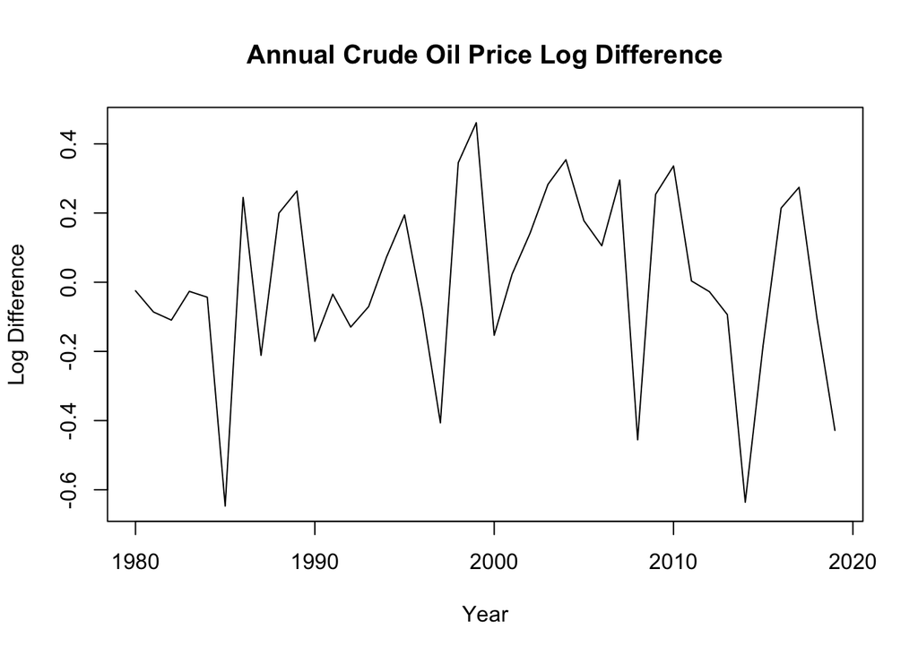

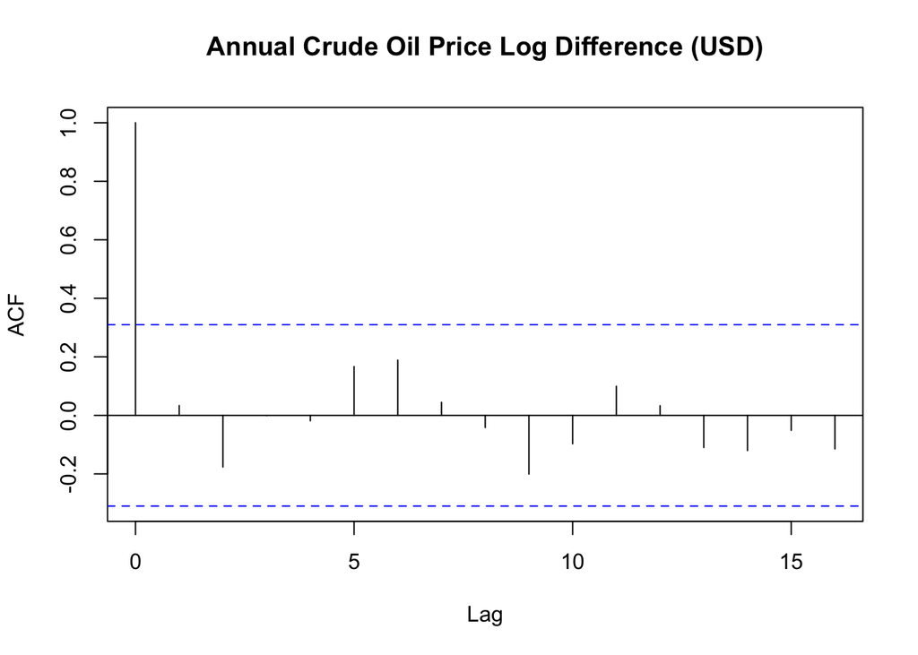

**3. GARCH Model Analysis**

The ARCH(p) model is the model of an p autogressive conditional heteroskedasticity model, which has the form $Y_n = \epsilon_n \sqrt V_n$ where $\epsilon_{1:N}$ is white noise and $V_n = \alpha_0 + \sum_{j=1}^{p} \alpha_j Y^2_{n-j}$$^{5}$.
The generalized ARCH model, also known as GARCH(p, q), has the form: $Y_n=\epsilon_n \sqrt{V_n}$, where $V_n=\alpha_0 + \sum_{j=1}^{p} \alpha_j Y^2_{n-j} + \sum_{k=1}^{q} \beta_k V_{n-k}$ and $\epsilon_{1:N}$ is white noise$^{5}$.

3.1 GARCH Model Fitting

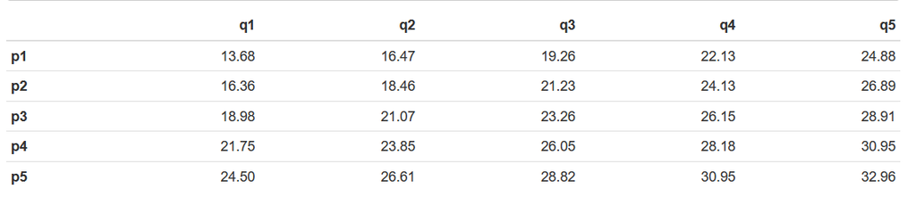

From the table above, we can see that GARCH(1,1) model is most ideal due to its lowest AIC value, which is also a popular choice (Cowpertwait and Metcalfe, 2009)$^{5,6}$.

3.2 GARCH Model Diagnostics  
Our GARCH(1,1) model has a log-likelihood of -3.331448, which will be used as a baseline for further comparison with our POMP model$^{6}$.

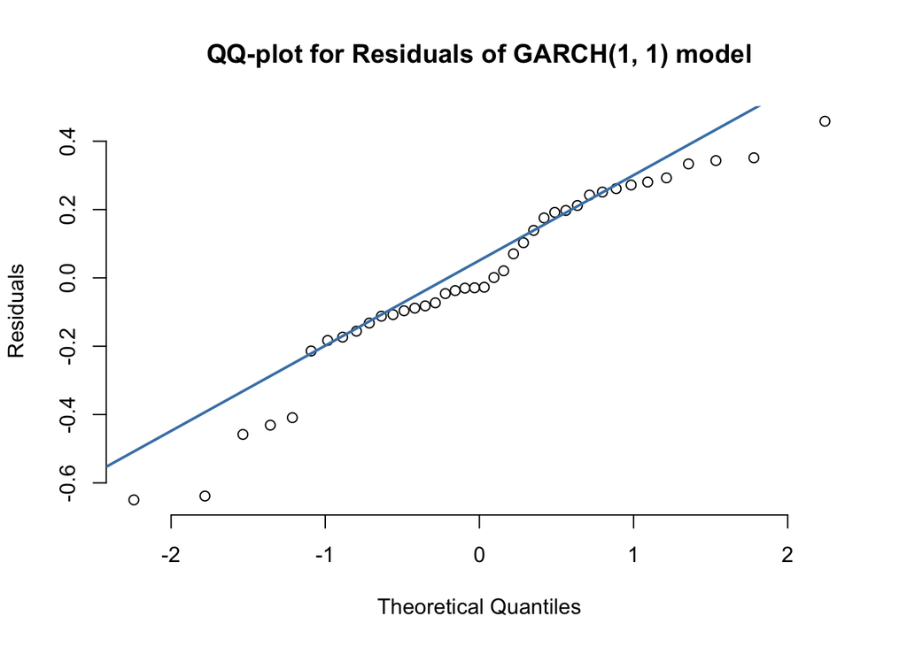

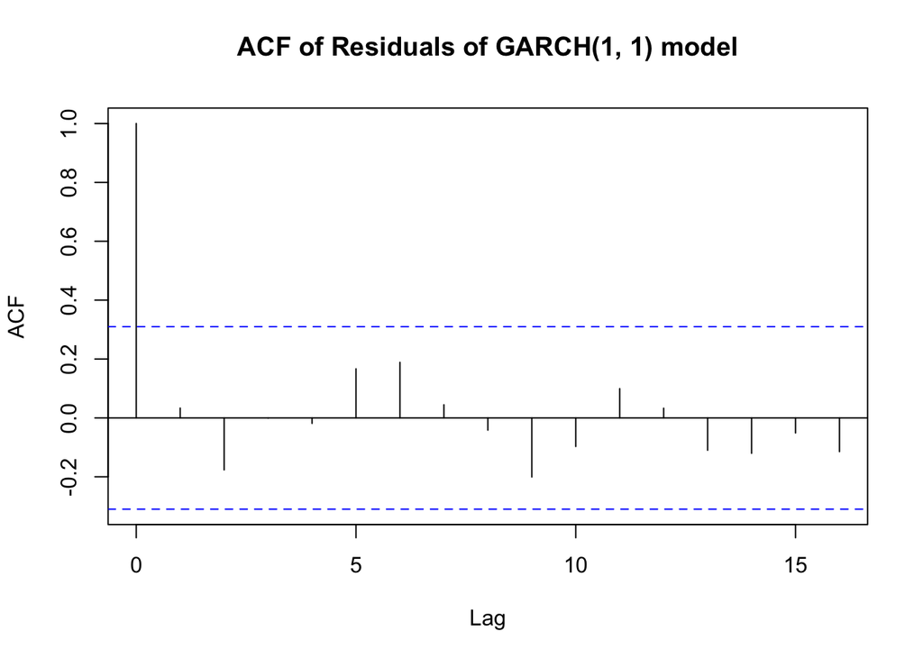

As shown in the figures above, the residuals of GARCH(1, 1) model are heavy-tailed and there is no significant autocorrelation when lag is greater than 0.

**4. ARMA Model Analysis**

Since we don’t observe any obvious periodical pattern in our data, so we will just consider ARMA($p$, $q$) here instead of the one with period and seasonality involved.

ARMA($p$, $q$) model is given by $Y_n$ = $\phi_1Y_{n-1} + \phi_2Y_{n-2} + ... + \phi_pY_{n-p} + \epsilon_n + \psi_1\epsilon_{n-1}+...+\psi_q\epsilon_{n-q}$, where {$\epsilon_n$} is a white noise process with mean 0 and variance $\sigma^2$; $\phi_1 ...\phi_p$ is the coefficients of AR components, and $\psi_1 ...\psi_q$ is the coefficients of MA component. Furthermore, based on what we discussed in the class, using the backshift operator $B$, we can rewrite it more succinctly as : $^{5}$

$\phi(B)(Y_n - \mu) = \psi(B)\epsilon_n$.

We use the Akaike information criterion (AIC) as the criterion for model selection among different choices of $p$ and $q$ for ARMA($p$, $q$) models. AIC is defined by $-2 \times \ell(\theta^*) + 2D$, where $\theta^*$ is the maximum value of the likelihood function for the model, and $D$ represents the number of estimated parameters in the model. Models with lower AIC values are usually preferred. Although based on what have discussed in class, AIC may have weak statistical properties when being viewed as a hypothesis test, it is still useful for narrowing down models choices with reasonable predictive performances.

|  | MA 0 | MA 1 | MA 2 | MA 3 | MA 4 | MA 5 |
| --- | --- | --- | --- | --- | --- | --- |
| AR 0 | 10.86999 | 12.79574 | 13.43893 | 15.35390 | 17.18950 | 16.78257 |
| AR 1 | 12.82316 | 14.03900 | 15.36611 | 16.06957 | 16.62043 | 17.01141 |
| AR 2 | 13.50763 | 15.47364 | 17.36586 | 14.92712 | 16.92538 | 18.11608 |
| AR 3 | 15.50465 | 17.36958 | 19.32842 | 17.21675 | 17.84248 | 16.12324 |
| AR 4 | 17.41548 | 19.18174 | 18.97390 | 18.77001 | 18.94766 | 20.35303 |

From the table above, the recommended model is ARMA(0,0), which has the lowest AIC value. It’s worth noticing that ARMA(0,0) is essentially a white noise model which is represented by $Y_n = \mu+\epsilon_n$, where {$\epsilon_n$} ~i.i.d. $N(0,\sigma^2)$. This means the model contains neither autoregressive nor moving average terms, which implies that the errors are uncorrelated across time. Thus, this white noise model won’t give us too much information about the oil price and the model fitting goodness, and the lowest AIC of it may be due to the limited size of our data. Based on this, for the analysis purpose, we would like to consider the model with second lowest AIC value, which is ARMA(0,1). On the other hand, since higher AIC value might imply that there are some dependence relationships involved for the oil price between two successive years in this context, thus, we also pick ARMA(4,5) for the further comparison.

To choose the model between ARMA(0,1) and ARMA(4,5), we use Wilk’s approximation as the likelihood ratio test for hypothesis test, with the null hypothesis of choosing model ARMA(0,1) and alternative hypothesis of choosing model ARMA(4,5).

According to the definition, the approximation under the null hypothesis is:

$l_1 - l_0 \approx (1/2)\chi^2_{D_1-D_0}$,

where $l_1$ and $l_0$ are the log likelihood maximization over $H_1$ and $H_0$, respectively; $D_1$ and $D_0$ are the number of parameters (dimension) under each hypothesis; $\chi^2_d$ is a chi-squared random variable on $d$ degrees of freedom; and $\approx$ means “is approximately distributed as”.

With this approximation, we can calculate the test statistics and when $l_1 - l_0$ is greater than the $(1/2)\chi^2_8$, we will reject $H_0$ (Since the reject region should be ($(1/2)\chi^2_8$, $\infty$) ). Computing by R, the value of $l_1 - l_0$ is 4.221351, which is less than $(1/2)\chi^2_8$ = 7.753657 at alpha = 0.05. Thus, we don’t reject $H_0$ at $\alpha = 0.05$, and conclude that we should select ARMA(0,1) based on the Wilk’s approximation.

#### Diagnostic plots for the ARMA model

Now, we are going to check the basic assumptions for the ARMA model.

##### Causality and Invertibility

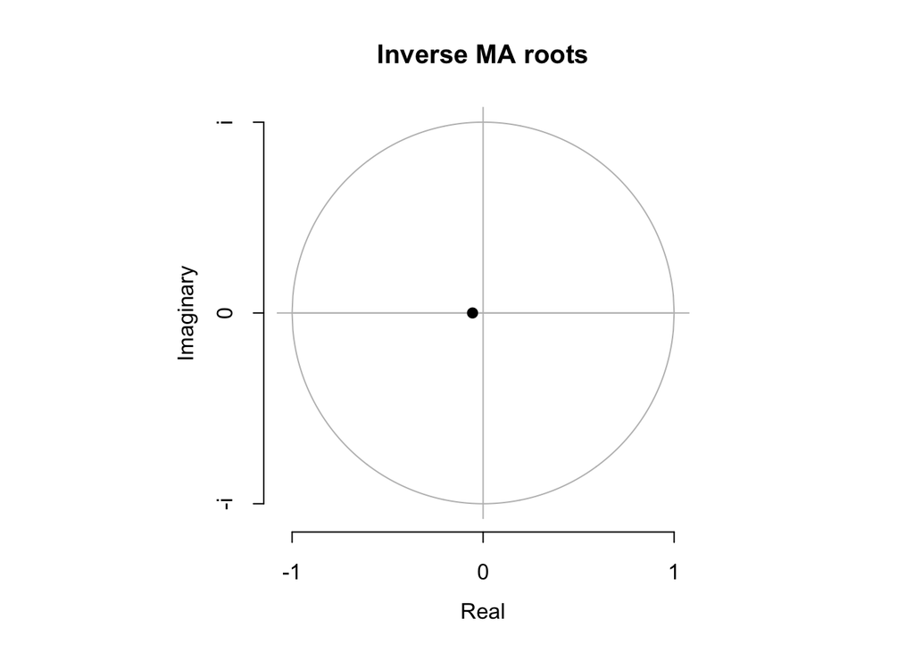

By looking at the plot for roots of the AR and MA polynomials, we can see since the $p$ component for AR is 0 in our case, and there is only one root for the MA component, where the inverse of it is within the unit circle. That is, the absolute values of MA roots are greater than 1, which means the fitted model is invertible.

##### Normality

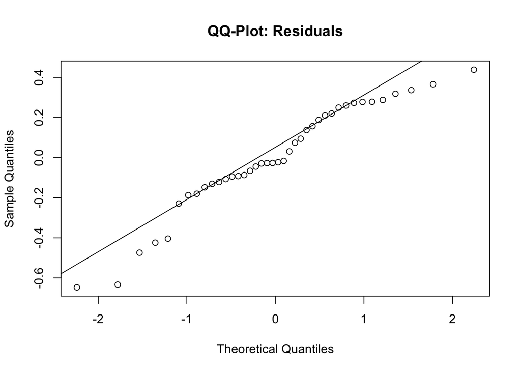

**5. POMP Model Analysis**

5.1 Build the POMP model

$$\begin{align}
Y_n &= exp(H_n/2) \epsilon_n \\
H_n &= \mu_h (1-\phi) + \phi H_{n-1} + \beta_{n-1} R_n exp(-H_{n-1}/2) + \omega_n \\
G_n &= G_{n-1}+\nu_n \\
\end{align}$$

where,
$$\begin{align}
\beta_n &= Y_n \sigma_{\eta} \sqrt{1-\phi^2} \\
\sigma_{\omega} &= \sigma_{\eta} \sqrt{1-\phi^2} \sqrt{1-R_n^2} \\
\epsilon_n &\overset{i.i.d}{\sim} N(0, 1) \\
\nu_n &\overset{i.i.d}{\sim} N(0, \sigma_{\nu}^2) \\
\omega_n &\overset{i.i.d}{\sim} N(0, \sigma_{\omega}^2) \\
Rn &= \frac{exp(2G_n)-1}{exp(2G_n)+1}
\end{align}$$

Here, we perform a series of steps to build POMP Model. First, two different POMP objects are built: one is for filtering and the other one is for simulation. After that, parameter transformations are conducted to do optimization procedures such as iterated filtering.$^{7}$ The pomp object, which is suitable for filtering is also built and then the model is simulated, and the parameters are initialized randomly as well.$^{7}$

5.2 Filtering on simulated data

```
                       se
-65.07335642   0.01206845
```

We obtain a log likelihood estimate of -65.07335642 with a Monte Carlo standard error of 0.01206845.

5.3 MLE from local search

The iterated filtering algorithm, also known as IF2, of lonides was used here. This procedure theoretically converges toward the region of parameter space where maximizing the maximum likelihood.$^{8}$

```
   user  system elapsed
499.574   7.918 134.869
```

```
Resulting log likelihood values:
```

```
   Min. 1st Qu.  Median    Mean 3rd Qu.    Max.
 -2.931  -2.925  -2.922  -2.922  -2.919  -2.909
```

```
Point estimates of log likelihood and parameters:
```

```
logLik    -2.9089474934
logLik_se  0.0006050061
sigma_nu   0.0110668412
mu_h      -2.3075042546
phi        0.9299229690
sigma_eta  0.0384124579
G_0        0.5255061678
H_0       -3.3873146780
```

```
Best AIC:  17.81789
```

The best AIC is around 17.81789. The maximum likelihood is -2.909. We also check the diagnostic plots to see whether we could improve the model further.

#### Diagnostic plots for the maximization procedure

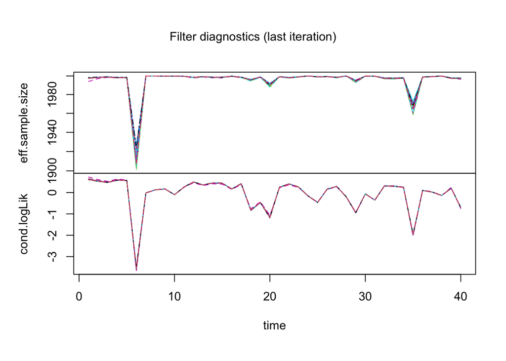

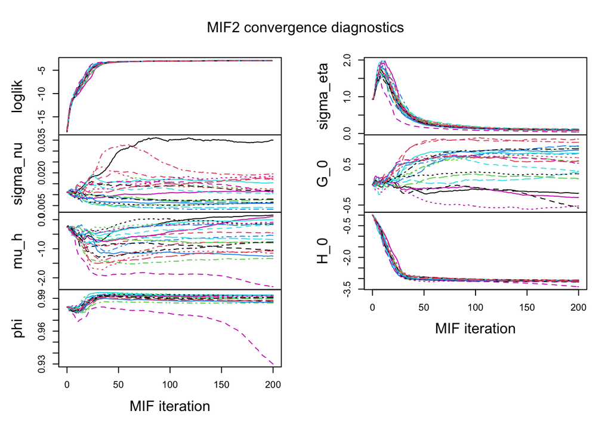

The convergence plots show that some parameters could not converge very well.

The plausible range for each parameter can be seen by plotting the pairs plot for log-likelihood and parameters:

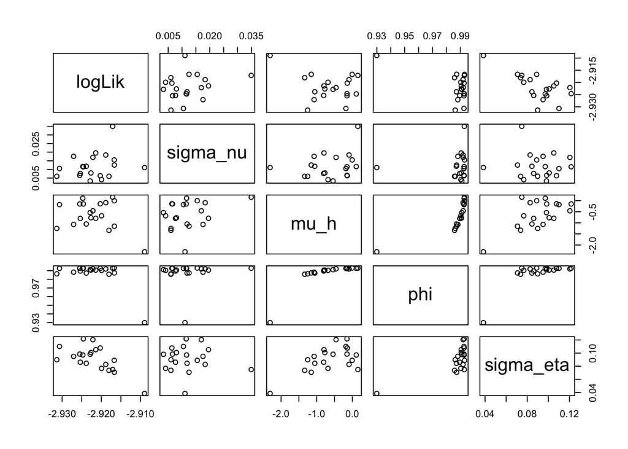

We find that $\sigma_{\nu}$ has the range in 0.005 to 0.020; $\mu_{h}$ has the range in -1.5 to 0; $\phi$ is focus on 0.99; and $\sigma_{\eta}$ has the range from 0.08 to 0.12.

5.4 MLE from global search

From the graph above, a large box of parameters can be tried to reach global maximization:

$$\sigma_\nu \in (0.005,0.020) \\
\mu_h \in (-1.5,0)\\
\phi \in (0.98,0.99)\\
\sigma_{\eta} \in (0.08,0.12)\\
G_0 \in (-2,2)\\
H_0 \in (-1,1)$$

```
Resulting log likelihood values:
```

```
   Min. 1st Qu.  Median    Mean 3rd Qu.    Max.
 -3.242  -2.925  -2.917  -2.905  -2.913  -2.225
```

```
Point estimates of log likelihood and parameters:
```

```
logLik    -2.2247882431
logLik_se  0.0006180195
sigma_nu   3.5940750892
mu_h      -2.5611369643
phi        0.7183664974
sigma_eta  0.0426707700
G_0       -0.9851877186
H_0       -4.6612062595
```

```
Best AIC:  16.44958
```

#### Diagnostic plots for the maximization procedure

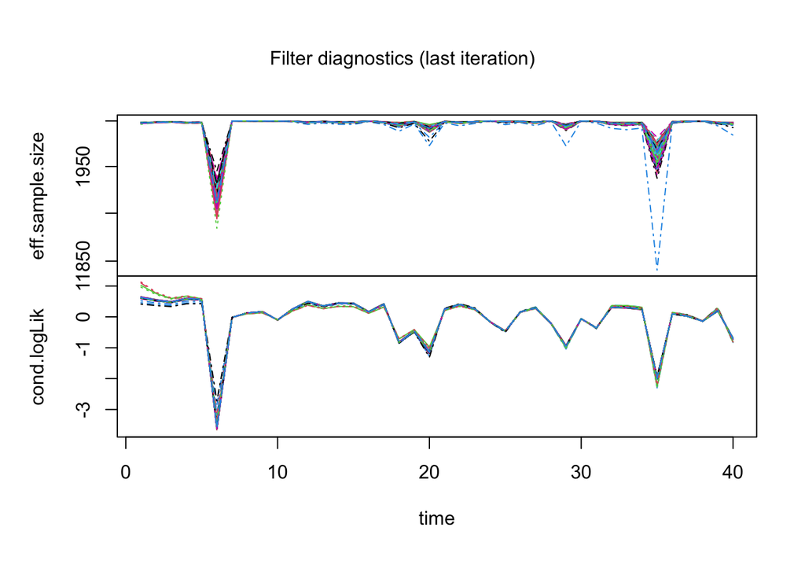

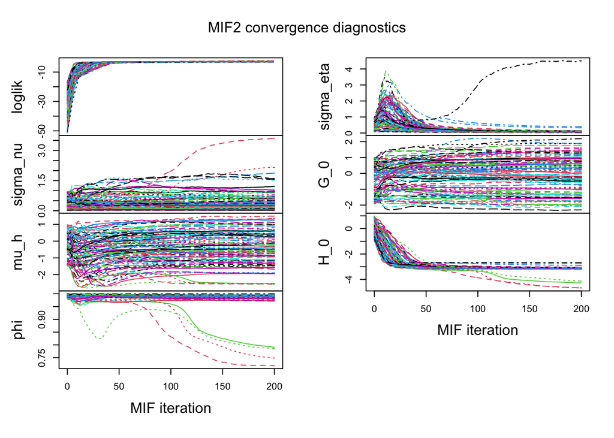

[figure not shown]

5.5 profile likelihood over $\phi$

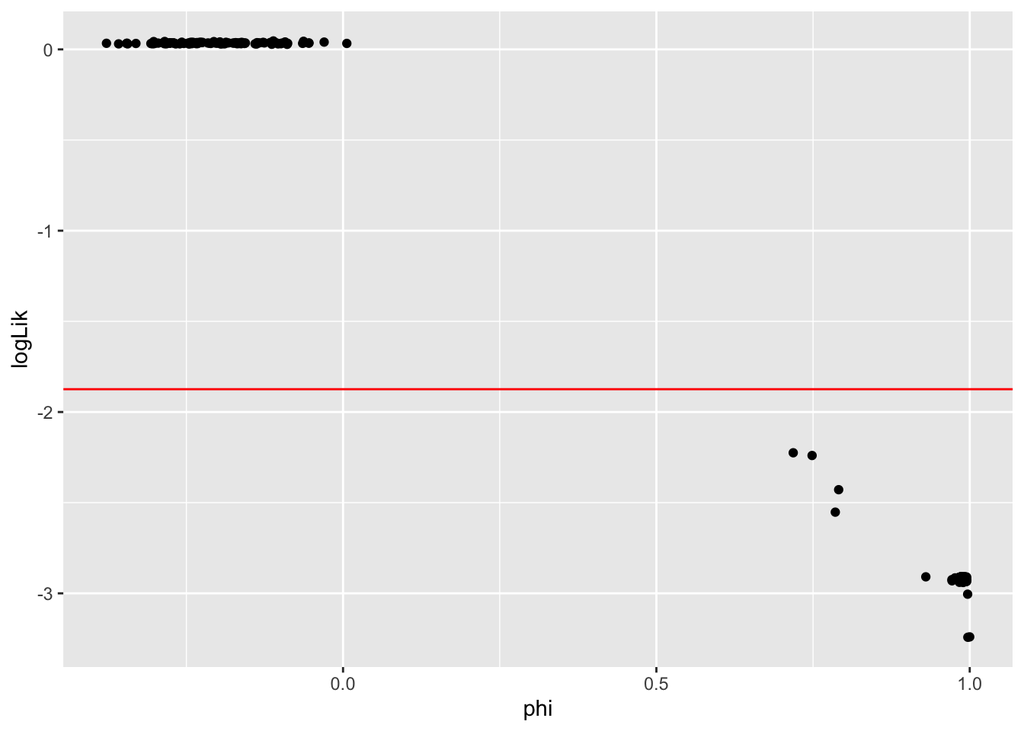

When $\phi$ is smaller than 0, stack of points lay above the threshold of the 95% confidence interval. However we need to be cautious of the points lay under the threshold line when phi is between 0.5 and 1.

**6. Conclusion**

After these analyses, we find that these models are appropriate for the time series analysis for the Crude oil price data set. Although due to time and computing resource limitations, shrinking data samples by selecting parts of the original data set as our analysis target may affect on the performance of the models (For instance, in the ARMA model analysis, it may result in the ARMA(0,0) corresponding to the lowest AIC value), we still obtain the reasonable analysis results from the data. In the future work, we may try to increase the size of the data set to see if there is any further interesting finding.

**7. References**  
[1] Wikipedia: Crude oil. URL:https://en.wikipedia.org/wiki/Petroleum#Uses. access at 04/09/2022.  
[2] Investopedia: How Oil Prices Impact the U.S. Economy. URL:https://www.investopedia.com/articles/investing/032515/how-oil-prices-impact-us-economy.asp#:~:text=The%20price%20of%20oil%20influences,costs%20and%20cheaper%20airline%20tickets. access at 04/09/2022.

[3] “Crude Oil Prices.” Our World in Data, https://ourworldindata.org/grapher/crude-oil-prices?time=earliest..latest. access at 04/09/2022.

[4] Forbes. URL: https://www.forbes.com/sites/forbesbooksauthors/2021/01/25/factors-that-influence-pricing-of-oil-and-gas/?sh=525908b9338d. access at 04/09/2022.

[5] Lecture Notes, Chapter 4: “Linear time series models and the algebra of ARMA models”. URL: https://ionides.github.io/531w22/04/notes.pdf. access at 04/10/2022.

[6] Lecture Notes, Chapter 16: A case study of financial volatility and a POMP model with observations driving latent dynamics”. URL: https://ionides.github.io/531w22/16/notes.pdf. access at 04/11/2022.

[7] Final Project 2021: Volatility analysis on the Shanghai Composite Index. URL: https://github.com/ionides/531w21/blob/main/final_project/project16/blinded.Rmd. access at 04/12/2022.

[8] Lecture Notes, Chapter 12: “Simulation of stochastic dynamic models”. URL: https://ionides.github.io/531w20/12/notes12.pdf. access at 04/14/2022.

[9] Lecture Notes, Chapter 14: “Likelihood maximization for POMP models”. URL: https://ionides.github.io/531w20/14/notes14.pdf. access at 04/14/2022.